# Ch02 Income2

Bruce Hartman

University of St. Francis

2026-10-14 Revised 2026-10-14T12:05:41

Abstract

We analyze the Income data from Chapter 2 of ISLR, in an R Notebook. We make the graphs in Section 2.1.2.

# Introduction

In this notebook we will analyze the Income dataset according to the book, as described in Reference 1 page 17.

One of the things we will show is how to display information in 3D plots. This is only useful when there are exactly two drivers in our regression. We need to do analysis based on the numeric summaries only for more than two drivers. However, we can get a good understanding of how regression works in multiple regressions by using 3D visualizations for examples with two drivers, as we do here.

You will be able to see the regression plane clearly, and also why the chosen plane is a good fit. It’s also useful to see how the data range about the chosen plane. Outliers that look numerically like outliers may not be changing the regression plane at all, or may be having a big effect.

# Packages

First we want to make all the packages for the course available, using `mbadtools`.

```r
library(ISLR2) # some data files
if(!("mbadtools" %in% installed.packages())) pak::pak("bhartman2/mbadtools")
library(mbadtools)
```

We add some packages for 3D plotting, a mysterious art.

```r
# some packages for 3D plotting; don't regularly add them.
library(rgl)
library(plotly)
```

# Data

The data we will use is from the `Income2` dataset. We are following the book starting at about page 18, where it introduces this data. The data is not in the `ISLR2` package. We have a csv file for this data. The columns are:

- an ID for each of 30 individuals
- Education in years of education
- Seniority in months on the job
- Income in of thousands of dollars

We will read in the data from the Income2.csv file using the *Import Dataset* capability in the RStudio upper right panel. We can look on our computer for the data, and make sure the instructions for fetching it are matched to our computer. Copy the code used to read the data correctly and place it here for reproducibility.

```r
library(readr)
Income <- read_csv("Income2.csv", show_col_types = FALSE)
Income
```

| ...1 | Education | Seniority | Income |
| --- | --- | --- | --- |
| 1 | 21.58621 | 113.10345 | 99.91717 |
| 2 | 18.27586 | 119.31034 | 92.57913 |
| 3 | 12.06897 | 100.68966 | 34.67873 |
| 4 | 17.03448 | 187.58621 | 78.70281 |
| 5 | 19.93103 | 20.00000 | 68.00992 |
| 6 | 18.27586 | 26.20690 | 71.50449 |
| 7 | 19.93103 | 150.34483 | 87.97047 |
| 8 | 21.17241 | 82.06897 | 79.81103 |
| 9 | 20.34483 | 88.27586 | 90.00633 |
| 10 | 10.00000 | 113.10345 | 45.65553 |

[output cut: 20 more lines]

Notice that all columns are numeric data coded as above. We will change the name of the first column to `ID`.

```r
Income = Income %>% rename(ID=`...1`)
```

# Data Description

Next we always describe the data so we know what the columns are called, how much data there is, and the range of values present.

```r
Income %>% glimpse
```

```
Rows: 30
Columns: 4
$ ID        <dbl> 1, 2, 3, 4, 5, 6, 7, 8, 9, 10, 11, 12, 13, 14, 15, 16, …
$ Education <dbl> 21.58621, 18.27586, 12.06897, 17.03448, 19.93103, 18.27…
$ Seniority <dbl> 113.10345, 119.31034, 100.68966, 187.58621, 20.00000, 2…
$ Income    <dbl> 99.91717, 92.57913, 34.67873, 78.70281, 68.00992, 71.50…
```

```r
Income %>% skim
```

```
── Data Summary ────────────────────────
                           Values
Name                       Piped data
Number of rows             30
Number of columns          4
_______________________
Column type frequency:
  numeric                  4
________________________
Group variables            None
```

|  | skim_variable | n_missing | complete_rate | mean | sd | p0 | p25 | p50 | p75 | p100 | hist |
| --- | --- | --- | --- | --- | --- | --- | --- | --- | --- | --- | --- |
| 1 | ID | 0 | 1 | 15.50000 | 8.803408 | 1.00000 | 8.25000 | 15.50000 | 22.75000 | 30.00000 | ▇▇▇▇▇ |
| 2 | Education | 0 | 1 | 16.38621 | 3.810622 | 10.00000 | 12.48276 | 17.03448 | 19.93103 | 21.58621 | ▇▂▂▆▇ |
| 3 | Seniority | 0 | 1 | 93.86207 | 55.715623 | 20.00000 | 44.82759 | 94.48276 | 133.27586 | 187.58621 | ▇▂▇▂▃ |
| 4 | Income | 0 | 1 | 62.74473 | 27.013285 | 17.61359 | 36.39204 | 70.80479 | 85.93061 | 99.91717 | ▆▂▂▇▇ |

We see that there are 30 rows of data, and 4 numeric columns. The `Education` column ranges from 10 to 21 years, `Seniority` from 20 to 187 months, and `Income` from 17.6 to 99.9 (in thousands of dollars). The min column is called `p0` and the max `p100`. Page over to see them.

# Research Question

We would like to know whether `Income`, the target, is related to `Education` and `Seniority`, the drivers.

- H1: `Income` is positively related to `Education`
- H2: `Income` is positively related to `Seniority`
- H3: `Income` is positively related to both `Education` and `Seniority` simultaneously.

# More Description

A pairs plot tells us correlations and gives us small graphs of the one variable against another. We’ll select just the columns we choose to look at.

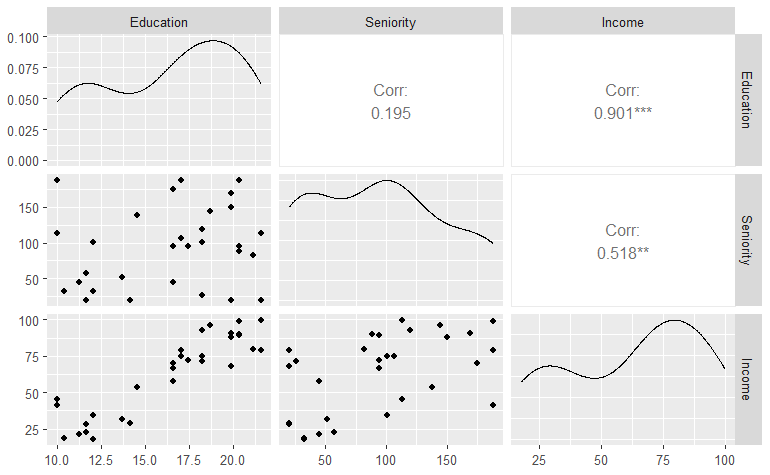

```r
Income %>% select(Education, Seniority, Income) %>% ggpairs(progress=FALSE)
```

`Income` and `Education` seem to be highly correlated, but `Income` is only moderately correlated with `Seniority`. But both correlations are positive, which is what we might expect from our hypotheses.

# Visualizing Data

Let’s plot Income against Seniority and then Education. For Education, this correspond to the left graph in Reference 1 Figure 2.2.

This data is simulated, not real data; the right picture in the graph shows the ‘true’ underlying relation, an s-shaped curve plus a random variation from it. We will not reproduce the right graph.

We will use a black and white theme.

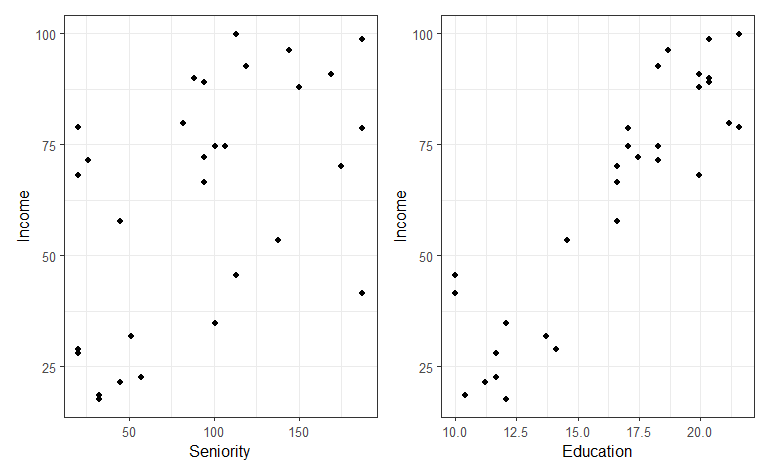

```r
# put first plot in `p1` object
p1=ggplot(Income) +
  geom_point(aes(x=Seniority, y=Income))+
  theme_bw()
# put second plot in `p2` object
p2=ggplot(Income) +
  geom_point(aes(x=Education, y=Income))+
  theme_bw()
# use patchwork to display the plots side by side
p1+p2
```

`Income` seems to be strongly related to `Education`, and less strongly to `Seniority`.

We can say this because the `Education` points are ‘closer’ to some straight line through them. The `Seniority` points are much more dispersed. This reflects the correlation coefficients found with the pairs plot.

Note that these plots are also produced in the `ggpairs()` output above.

This is evidence against H1 and H2 being wrong for our data.

# 3D Plotting

In this section we will demonstrate several ways to make a 3D plot with R of `Income` vs `Education` and `Seniority`.

First we will try to replicate Figure 2.3 in the text.

We will try using the `rgl` package from R. To get the plot into your preview, we need to use the code after setting up `rgl`.

```r
# Figure 2.3 ------------
# not really the whole picture, but showing that 3D plots are possible
# don't forget to install rgl first
library(rgl)
setupKnitr(autoprint = TRUE)
plot3d(Income$Education,Income$Seniority,Income$Income, colvar=NULL,
          type="p", pch=16, col="red", ticktype="detailed",
          xlab="Years of Education",ylab="Seniority",zlab="Income")
```

[interactive chart not shown]

The plot shows the data cloud nicely and can be rotated to get different views.

# Linear Regression

We would like to quantify the relations suggested by H1-H3.

Let’s run a linear regression model of Income ~ Seniority + Education to obtain data points for the fitted plane. Income is the *target* and the others are the *drivers*, a choice of words that implies some sort of cause.

But this is just mathematics, not any suggestion of cause and effect. Cause and effect would need further confirmation based on the analyst suggesting a mechanism by which an Education or Seniority increase would compel an increase in Income. We are not doing that here. After all the data is simulated!

We will create a regression object `fit.income` using the `lm()` function, and look at the results. This is the usual sequence of events in linear modeling. Plotting the residuals is essential for a linear model.

```r
fit.income = lm(Income~Education+Seniority, data=Income)
fit.income %>% glance
```

| r.squared | adj.r.squared | sigma | statistic | p.value | df | logLik | AIC | BIC | deviance | df.residual | nobs |
| --- | --- | --- | --- | --- | --- | --- | --- | --- | --- | --- | --- |
| 0.9341035 | 0.9292223 | 7.186634 | 191.3669 | 1.134064e-16 | 2 | -100.1544 | 208.3089 | 213.9137 | 1394.488 | 27 | 30 |

```r
fit.income %>% tidy(conf.int=TRUE)
```

| term | estimate | std.error | statistic | p.value | conf.low | conf.high |
| --- | --- | --- | --- | --- | --- | --- |
| (Intercept) | -50.0856388 | 5.99877911 | -8.349305 | 5.850415e-09 | -62.3941168 | -37.7771607 |
| Education | 5.8955560 | 0.35703114 | 16.512722 | 1.230258e-15 | 5.1629886 | 6.6281233 |
| Seniority | 0.1728555 | 0.02441884 | 7.078775 | 1.304884e-07 | 0.1227522 | 0.2229588 |

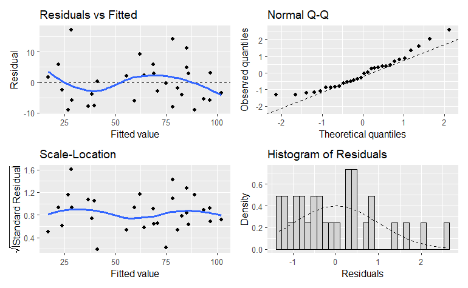

```r
fit.income %>% gg_residual_plots
```

Look at the `glance` output. What is Adjusted R-squared? Is the regression significant or not? The null hypothesis that all coefficients are zero. The alternate hypothesis is that at least one is not zero. How do we tell?

Look at the `tidy` output. Which individual coefficients are significant? Null hypothesis = a coefficient is 0, alternate is that coefficient is not zero.

There is an estimation error for the coefficients; they might not really be exactly what the numbers show, but we would like to know how confident we are that the exact values are nearby. Confidence intervals for the coefficients show us that.

In the `tidy` output we can see the coefficients, and 95% confidence intervals on each coefficient. There are also short functions `coef` and `confint` to see the coefficients and confidence intervals.

I will add into my text the values of the coefficients computed by R rather than typing out the numbers. Here is how to do it in the paragraph below.

We see that the `Education` coefficient is 5.895556, and the `Seniority` coefficient is estimated at 0.1728555.

Use the `gt_add_significance` function to add significance color to the table of coefficients.

```r
fit.income %>% tidy(conf.int=TRUE) %>% gt_add_significance()
```

| term | estimate | std.error | statistic | p.value | conf.low | conf.high |
| --- | --- | --- | --- | --- | --- | --- |
| (Intercept) | −50.0856 | 5.9988 | −8.3493 | 0.0000 | −62.3941 | −37.7772 |
| Education | 5.8956 | 0.3570 | 16.5127 | 0.0000 | 5.1630 | 6.6281 |
| Seniority | 0.1729 | 0.0244 | 7.0788 | 0.0000 | 0.1228 | 0.2230 |

The confidence interval for the `Education` coefficient shows us that there is a 95% chance that the coefficient is really between 5.16 and 6.63. The confidence interval for the `Seniority` coefficient shows us that there is a 95% chance that the coefficient is really between 0.122 and 0.223.

# Residuals

Look at the residual plots. Do residuals follow the 4 assumptions of regression?

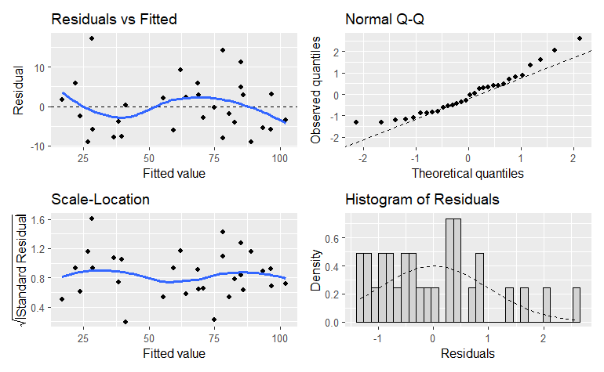

```r
fit.income %>% gg_residual_plots()
```

# Fitted Values

```r
predict(fit.income) %>% head(10)
```

```
       1        2        3        4        5        6        7        8
96.72760 78.28417 38.47238 82.76741 70.87600 62.19073 93.40682 88.92358
       9       10
85.11740 28.42047
```

```r
fit.income %>% augment
```

| Income | Education | Seniority | .fitted | .resid | .hat | .sigma | .cooksd | .std.resid |
| --- | --- | --- | --- | --- | --- | --- | --- | --- |
| 99.91717 | 21.58621 | 113.10345 | 96.72760 | 3.1895710 | 0.09777431 | 7.293866 | 7.886542e-03 | 0.46724981 |
| 92.57913 | 18.27586 | 119.31034 | 78.28417 | 14.2949604 | 0.04646525 | 6.737338 | 6.739827e-02 | 2.03699118 |
| 34.67873 | 12.06897 | 100.68966 | 38.47238 | -3.7936533 | 0.08180890 | 7.282260 | 9.013165e-03 | -0.55089084 |
| 78.70281 | 17.03448 | 187.58621 | 82.76741 | -4.0646032 | 0.13179548 | 7.273395 | 1.864320e-02 | -0.60699008 |
| 68.00992 | 19.93103 | 20.00000 | 70.87600 | -2.8660781 | 0.14452663 | 7.298277 | 1.046981e-02 | -0.43118062 |
| 71.50449 | 18.27586 | 26.20690 | 62.19073 | 9.3137512 | 0.10338650 | 7.064918 | 7.199962e-02 | 1.36866276 |
| 87.97047 | 19.93103 | 150.34483 | 93.40682 | -5.4363491 | 0.08803092 | 7.237938 | 2.018912e-02 | -0.79212139 |
| 79.81103 | 21.17241 | 82.06897 | 88.92358 | -9.1125513 | 0.09518412 | 7.078446 | 6.230913e-02 | -1.33301285 |
| 90.00633 | 20.34483 | 88.27586 | 85.11740 | 4.8889307 | 0.07382245 | 7.255453 | 1.327564e-02 | 0.70687271 |
| 45.65553 | 10.00000 | 113.10345 | 28.42047 | 17.2350590 | 0.14633481 | 6.344353 | 3.849690e-01 | 2.59563394 |

[output cut: 20 more lines]

`augment` does a better job. The `augment` function is good for predictions and lots of other info. With the parameter ‘interval=“confidence”’ we can get confidence intervals on each prediction (fitted value).

```r
fit.income %>% augment(interval="confidence")
```

| Income | Education | Seniority | .fitted | .lower | .upper | .resid | .hat | .sigma | .cooksd | .std.resid |
| --- | --- | --- | --- | --- | --- | --- | --- | --- | --- | --- |
| 99.91717 | 21.58621 | 113.10345 | 96.72760 | 92.11677 | 101.33843 | 3.1895710 | 0.09777431 | 7.293866 | 7.886542e-03 | 0.46724981 |
| 92.57913 | 18.27586 | 119.31034 | 78.28417 | 75.10561 | 81.46274 | 14.2949604 | 0.04646525 | 6.737338 | 6.739827e-02 | 2.03699118 |
| 34.67873 | 12.06897 | 100.68966 | 38.47238 | 34.25476 | 42.69000 | -3.7936533 | 0.08180890 | 7.282260 | 9.013165e-03 | -0.55089084 |
| 78.70281 | 17.03448 | 187.58621 | 82.76741 | 77.41416 | 88.12066 | -4.0646032 | 0.13179548 | 7.273395 | 1.864320e-02 | -0.60699008 |
| 68.00992 | 19.93103 | 20.00000 | 70.87600 | 65.27016 | 76.48184 | -2.8660781 | 0.14452663 | 7.298277 | 1.046981e-02 | -0.43118062 |
| 71.50449 | 18.27586 | 26.20690 | 62.19073 | 57.44942 | 66.93205 | 9.3137512 | 0.10338650 | 7.064918 | 7.199962e-02 | 1.36866276 |
| 87.97047 | 19.93103 | 150.34483 | 93.40682 | 89.03175 | 97.78188 | -5.4363491 | 0.08803092 | 7.237938 | 2.018912e-02 | -0.79212139 |
| 79.81103 | 21.17241 | 82.06897 | 88.92358 | 84.37423 | 93.47293 | -9.1125513 | 0.09518412 | 7.078446 | 6.230913e-02 | -1.33301285 |
| 90.00633 | 20.34483 | 88.27586 | 85.11740 | 81.11093 | 89.12386 | 4.8889307 | 0.07382245 | 7.255453 | 1.327564e-02 | 0.70687271 |
| 45.65553 | 10.00000 | 113.10345 | 28.42047 | 22.77967 | 34.06127 | 17.2350590 | 0.14633481 | 6.344353 | 3.849690e-01 | 2.59563394 |

[output cut: 20 more lines]

If we want to predict some other data it can be done with the ‘newdata’ parameter. The new data must be a dataframe with the same columns as the drivers in the regression. Supply a dataframe with the driver data you want to make a prediction for.

```r
new_data = data.frame(Education=c(12,14,16), Seniority=c(20,40,60))
fit.income %>% augment(newdata=new_data,
                       se.fit=TRUE,
                       interval="confidence")
```

| Education | Seniority | .fitted | .lower | .upper |
| --- | --- | --- | --- | --- |
| 12 | 20 | 24.11814 | 18.95656 | 29.27972 |
| 14 | 40 | 39.36636 | 35.39758 | 43.33514 |
| 16 | 60 | 54.61458 | 51.44920 | 57.77997 |

# 3D Viz with `rgl`

```r
# rgl fitted plane and points in red
plot3d(fit.income, which=1 , plane.alpha=0.7, plane.col = "yellow",
       do_grid=TRUE, grid.steps=10, sub.steps=3, grid.alpha=0.9, grid.col="black",
       col="red", size=8,
       main="Figure 2.4")
```

[interactive chart not shown]

You can in the preview grab the plot and twist it around, or zoom it.

There’s more we can do with the `rgl` package. Here is a graph showing the data points and allowing you to see the residuals.

```r
plot3d(fit.income, which=2, plane.alpha=0.1,
       do_grid=TRUE, grid.steps=10,sub.steps=3,grid.alpha=0.5,grid.col="gray",
       col="blue", size=8)
```

[interactive chart not shown]

We can show the fitted plane and the predicted or fitted values in green.

```r
plot3d(fit.income, which=3, plane.alpha=0.1, plane.col = "green",
       do_grid=TRUE, grid.steps=10,sub.steps=3,grid.alpha=0.5,grid.col="gray",
       col="green", size=6,
       xlab="", ylab="", zlab="")
```

[interactive chart not shown]

We can add the raw data to the predicted plot. We redo the last plot and run another `plot3d` with the parameter setting ‘add=TRUE’.

```r
plot3d(fit.income, which=3, plane.alpha=0.1, plane.col = "green",
       do_grid=TRUE, grid.steps=10,sub.steps=3,grid.alpha=0.5,grid.col="gray",
       col="green", size=6,
       xlab="", ylab="", zlab="")
```

[interactive chart not shown]

```r
plot3d(Income$Education, Income$Seniority, Income$Income, type="p", size=8, col="red",
       top=TRUE, add=TRUE,
       xlab="", ylab="", zlab="")
```

[interactive chart not shown]

```r
# # name the axes
decorate3d(xlab="Years of Education", ylab="Months of Seniority",zlab="Income (000)")
```

[interactive chart not shown]

This is not perfect, but it is pretty. Notice how we decorate the axes with names.

The minimal statement you need to make an `rgl` plot is this:

```r
plot3d(fit.income)
```

[interactive chart not shown]

It is a lot nicer with color and care as with most visualizations.

These plots are nice, but they are not `ggplot` compatible; they don’t comply with the new grammar of graphics.

# 3D Viz with plotly

Another 3D plotting package is `plotly` which I will demonstrate here. It has some advantages; one is that it is a lot like `ggplot`, another is that it is designed for online user-manipulated images.

```r
library(plotly)
P = plot_ly(Income, x = ~Education, y = ~Seniority, z = ~Income)
library(htmltools)
tagList(P)
```

[interactive chart not shown]

You can maneuver the plot to see that there is actually a regression plane that goes through the data, making the actual data points pretty close to it.

Unlike the package `rgl`, you cannot simply add the plane in the basic plot function. You have to create the grid of `Education` and `Seniority` points, and calculate the fitted income values on it.

Here is how to do it, from Reference2. I added some comments and a few displays of the surface data at each stage so you can see what transformation was made.

First set up the axis points for the grid.

```r
#Graph Resolution (more important for more complex shapes)
graph_reso <- 0.5 # how far apart the points of the x-y grid are

#Setup Axis for x-y dimensions
axis_x <- seq(min(Income$Education), max(Income$Education), by = graph_reso)
axis_y <- seq(min(Income$Seniority), max(Income$Seniority), by = graph_reso)
```

From the axis points we create the grid points for the drivers and calculate the fitted `Income` values at each grid point.

```r
#Sample points
# create the x-y grid
driver_lm_surface <- expand.grid(Education = axis_x, Seniority = axis_y, KEEP.OUT.ATTRS = F)
# add in the Income values for each point in the x-y grid
driver_lm_surface$Income <- predict.lm(fit.income, newdata = driver_lm_surface)
# take a look
driver_lm_surface
```

| Education | Seniority | Income |
| --- | --- | --- |
| 10.0 | 20.0 | 12.32703 |
| 10.5 | 20.0 | 15.27481 |
| 11.0 | 20.0 | 18.22259 |
| 11.5 | 20.0 | 21.17036 |
| 12.0 | 20.0 | 24.11814 |
| 12.5 | 20.0 | 27.06592 |
| 13.0 | 20.0 | 30.01370 |
| 13.5 | 20.0 | 32.96148 |
| 14.0 | 20.0 | 35.90925 |
| 14.5 | 20.0 | 38.85703 |

[output cut: 990 more lines]

```r
x = driver_lm_surface %>%
  pivot_wider(names_from=Education, values_from=Income) %>%
  column_to_rownames(var="Seniority") %>%
  as.matrix
x %>% glimpse
```

```
 num [1:336, 1:24] 12.3 12.4 12.5 12.6 12.7 ...
 - attr(*, "dimnames")=List of 2
  ..$ : chr [1:336] "20" "20.5" "21" "21.5" ...
  ..$ : chr [1:24] "10" "10.5" "11" "11.5" ...
```

```r
driver_lm_surface_shaped = x
```

We obtain a matrix with 336 rows, 24 columns, and the `Income` values in each cell. The row names are the `Seniority` values on the grid, and the column names are the `Education` values on the grid.

Now we can plot the shaped surface with the data. I turned off the warnings for this chunk, since the plot functions generate a lot of them for no reason.

```r
# create the data plot
income_plot = plot_ly(Income,
                     x = ~Education,
                     y = ~Seniority,
                     z = ~Income,
                     type = "scatter3d",
                     mode = "markers")
# add a layer with the regression fitted plane
income_plot <- add_trace(p = income_plot,
                       z = driver_lm_surface_shaped,
                       x = axis_x,
                       y = axis_y,
                       type = "surface", alpha=.5)
# display the plot
income_plot
```

[interactive chart not shown]

```r
library(htmltools)
tagList(income_plot)
```

[interactive chart not shown]

Notice the plane is colored to show the value of `Income` at each point. The plot above can be manipulated with the mouse cursor.

# Conclusion

That’s all I can show you with 3D plotting, but you can create endless variations.

# References:

1. [ISLR (2013)] Chapter 2 Statistical Learning, page 17-24.
2. [Add Regression Plane to plot_ly](https://stackoverflow.com/questions/38331198/add-regression-plane-to-3d-scatter-plot-in-plotly)